# Geospatial I/O

Reading and writing geospatial data

This module provides GeoTIFF reading/writing, raster processing, and landscape data management for fire simulations.

```julia
using Elmfire
```

## Types

### GeoMetadata

Geospatial metadata for a raster dataset.

```julia
struct GeoMetadata{T<:AbstractFloat}
    ncols::Int          # Number of columns
    nrows::Int          # Number of rows
    cellsize::T         # Cell size (same units as CRS)
    xllcorner::T        # X coordinate of lower-left corner
    yllcorner::T        # Y coordinate of lower-left corner
    nodata_value::T     # NoData value
    crs::String         # Coordinate reference system (PROJ4 string)
    transform::NTuple{6,T}  # GDAL GeoTransform
end
```

**Constructor:**

```julia
GeoMetadata{T}(;
    ncols::Int,
    nrows::Int,
    cellsize::T,
    xllcorner = zero(T),
    yllcorner = zero(T),
    nodata_value = T(-9999),
    crs = "EPSG:4326",
    transform = nothing
)
```

The GDAL GeoTransform is a 6-element tuple: `(xmin, xres, xskew, ymax, yskew, -yres)`

```julia
metadata = GeoMetadata{Float64}(
    ncols = 100,
    nrows = 100,
    cellsize = 30.0,
    xllcorner = 0.0,
    yllcorner = 0.0,
    crs = "EPSG:32610"  # UTM Zone 10N
)

println("Grid size: $(metadata.ncols) x $(metadata.nrows)")
println("Cell size: $(metadata.cellsize)")
println("CRS: $(metadata.crs)")
```

```
Grid size: 100 x 100
Cell size: 30.0
CRS: EPSG:32610
```

### GeoRaster

A raster dataset with geospatial metadata.

```julia
struct GeoRaster{T<:AbstractFloat}
    data::Matrix{T}
    metadata::GeoMetadata{T}
end
```

```julia
# Create a simple raster
data = randn(Float64, 50, 50) .* 100 .+ 500  # Elevation-like data
metadata = GeoMetadata{Float64}(ncols=50, nrows=50, cellsize=30.0)
raster = GeoRaster{Float64}(data, metadata)

println("Raster size: $(size(raster))")
println("Data range: $(minimum(raster.data)) - $(maximum(raster.data))")
```

```
Raster size: (50, 50)
Data range: 159.89026390612355 - 803.7334479871188
```

### LandscapeData

Complete landscape data for fire simulation including fuel, topography, and canopy.

```julia
struct LandscapeData{T<:AbstractFloat}
    fuel_ids::Matrix{Int}                 # Fuel model IDs
    slope::Matrix{T}                      # Slope (degrees)
    aspect::Matrix{T}                     # Aspect (degrees from north)
    elevation::Matrix{T}                  # Elevation
    canopy::Union{Nothing, CanopyGrid{T}} # Optional canopy data
    metadata::GeoMetadata{T}              # Geospatial metadata
end
```

## Reading Functions

### read_geotiff

Read a GeoTIFF file and return a GeoRaster.

```julia
read_geotiff(::Type{T}, path::String) -> GeoRaster{T}
read_geotiff(path::String) -> GeoRaster{Float64}
```

The data is automatically transposed to match Julia’s column-major order.

### read_fuel_raster

Read a fuel model raster (integer fuel IDs) and return the matrix with metadata.

```julia
read_fuel_raster(::Type{T}, path::String) -> Tuple{Matrix{Int}, GeoMetadata{T}}
```

### read_dem

Read a Digital Elevation Model raster.

```julia
read_dem(::Type{T}, path::String) -> GeoRaster{T}
```

### read_landscape

Read a complete landscape dataset from GeoTIFF files.

```julia
read_landscape(::Type{T}, fuel_path, dem_path;
    cbd_path = nothing,    # Canopy bulk density
    cbh_path = nothing,    # Canopy base height
    cc_path = nothing,     # Canopy cover
    ch_path = nothing      # Canopy height
) -> LandscapeData{T}
```

**Example usage:**

```julia
# Read basic landscape
landscape = read_landscape(Float64,
    "fuel_model.tif",
    "elevation.tif"
)

# Read with canopy data for crown fire
landscape = read_landscape(Float64,
    "fuel_model.tif",
    "elevation.tif";
    cbd_path = "canopy_bulk_density.tif",
    cbh_path = "canopy_base_height.tif",
    cc_path = "canopy_cover.tif",
    ch_path = "canopy_height.tif"
)
```

## Writing Functions

### write_geotiff

Write a GeoRaster to a GeoTIFF file.

```julia
write_geotiff(path::String, raster::GeoRaster)
write_geotiff(path::String, data::Matrix, metadata::GeoMetadata)
```

### write_fire_perimeter

Write fire perimeter to a GeoJSON file.

```julia
write_fire_perimeter(path::String, state::FireState, metadata::GeoMetadata; format=:geojson)
```

## Terrain Processing

### compute_slope_aspect

Compute slope and aspect from a DEM using a 3x3 moving window.

```julia
compute_slope_aspect(dem::GeoRaster) -> Tuple{Matrix, Matrix}
compute_slope_aspect(elevation::Matrix, cellsize) -> Tuple{Matrix, Matrix}
```

Returns `(slope_degrees, aspect_degrees)` where: - Slope is in degrees (0-90) - Aspect is in degrees clockwise from north (0-360), with flat areas set to 0

```julia
# Create synthetic elevation data (a hill)
ncols, nrows = 100, 100
elevation = zeros(Float64, ncols, nrows)

for ix in 1:ncols
    for iy in 1:nrows
        # Distance from center
        dx = ix - 50
        dy = iy - 50
        dist = sqrt(dx^2 + dy^2)
        # Gaussian hill
        elevation[ix, iy] = 100 * exp(-dist^2 / 500)
    end
end

# Compute slope and aspect
slope, aspect = compute_slope_aspect(elevation, 30.0)

println("Slope range: $(round(minimum(slope), digits=1))° - $(round(maximum(slope), digits=1))°")
println("Aspect range: $(round(minimum(aspect), digits=1))° - $(round(maximum(aspect), digits=1))°")
```

```
Slope range: 0.0° - 7.3°
Aspect range: 0.0° - 358.8°
```

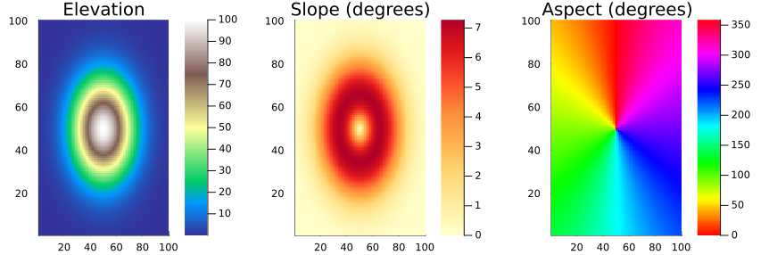

```julia
using Plots

p1 = heatmap(elevation', title = "Elevation", color = :terrain)
p2 = heatmap(slope', title = "Slope (degrees)", color = :YlOrRd)
p3 = heatmap(aspect', title = "Aspect (degrees)", color = :hsv)

plot(p1, p2, p3, layout = (1, 3), size = (900, 300))
```

## Coordinate Conversion

### grid_to_geo

Convert grid coordinates to geographic coordinates.

```julia
grid_to_geo(ix::Int, iy::Int, metadata::GeoMetadata) -> Tuple{T, T}
```

### geo_to_grid

Convert geographic coordinates to grid coordinates.

```julia
geo_to_grid(x::T, y::T, metadata::GeoMetadata) -> Tuple{Int, Int}
```

```julia
metadata = GeoMetadata{Float64}(
    ncols = 100,
    nrows = 100,
    cellsize = 30.0,
    xllcorner = 500000.0,  # UTM easting
    yllcorner = 4000000.0  # UTM northing
)

# Grid to geo
x, y = grid_to_geo(50, 50, metadata)
println("Grid (50, 50) -> Geo ($(x), $(y))")

# Geo to grid
ix, iy = geo_to_grid(x, y, metadata)
println("Geo ($(x), $(y)) -> Grid ($ix, $iy)")
```

```
Grid (50, 50) -> Geo (501485.0, 4.001515e6)
Geo (501485.0, 4.001515e6) -> Grid (50, 50)
```

## Resampling

### resample_to_match

Resample a raster to match the resolution and extent of a target raster.

```julia
resample_to_match(source::GeoRaster, target::GeoMetadata; method=:nearest) -> GeoRaster
```

Methods: - `:nearest` - Nearest neighbor (default, preserves discrete values like fuel IDs) - `:bilinear` - Bilinear interpolation (good for continuous data like elevation)

## Workflow Example

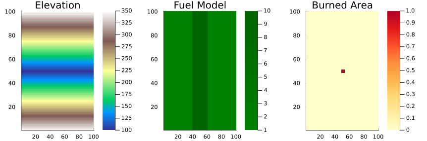

```julia
# This example shows the typical workflow for loading landscape data
# and running a simulation (using synthetic data since we don't have real files)

# Create synthetic landscape data
ncols, nrows = 100, 100
cellsize = 30.0

# Synthetic elevation (valley)
elevation = zeros(Float64, ncols, nrows)
for ix in 1:ncols, iy in 1:nrows
    elevation[ix, iy] = 100 + abs(iy - 50) * 5  # Valley at y=50
end

# Compute terrain from elevation
slope, aspect = compute_slope_aspect(elevation, cellsize)

# Synthetic fuel (grass with some timber)
fuel_ids = fill(1, ncols, nrows)  # Grass
fuel_ids[40:60, :] .= 10           # Timber along valley

# Create fire state
state = FireState{Float64}(ncols, nrows, cellsize)
fuel_table = create_standard_fuel_table(Float64)

# Weather
weather = ConstantWeather{Float64}(
    wind_speed_mph = 10.0,
    wind_direction = 270.0,
    M1 = 0.06, M10 = 0.08, M100 = 0.10,
    MLH = 0.60, MLW = 0.90
)

# Ignite and run
ignite!(state, 50, 50, 0.0)
simulate!(state, fuel_ids, fuel_table, weather, slope, aspect, 0.0, 30.0)

# Visualize results
p1 = heatmap(elevation', title = "Elevation", color = :terrain)
p2 = heatmap(fuel_ids', title = "Fuel Model", color = [:green, :darkgreen])
p3 = heatmap(state.burned', title = "Burned Area", color = :YlOrRd)

plot(p1, p2, p3, layout = (1, 3), size = (900, 300))
```

## Data Sources

Elmfire.jl can read landscape data from common sources:

| Data Type | Common Sources | File Format |
| --- | --- | --- |
| Fuel Models | LANDFIRE, FCCS | GeoTIFF |
| Elevation | USGS 3DEP, SRTM | GeoTIFF |
| Canopy | LANDFIRE | GeoTIFF |
| Weather | RTMA, RAP, HRRR | NetCDF, GRIB2 |

## Coordinate Reference Systems

Fire simulations require projected coordinates (not lat/lon) for accurate distance calculations. Common projections:

- **UTM** - Universal Transverse Mercator (e.g., EPSG:32610 for zone 10N)
- **Albers Equal Area** - Good for large areas (e.g., EPSG:5070 for CONUS)
- **State Plane** - US state-specific projections

All input rasters should be in the same CRS before loading.